# Untitled

Александрова Александра

06 04 2021

## Вариант № 2

1. Примените указанные в варианте метод к набору данных по своему варианту (см. таблицу ниже). Не забудьте предварительно сделать из категориальных переменных факторы. Выберите оптимальную модель с помощью кросс-валидации. Выведите её коэффициенты с помощью функции coef(). Рассчитайте MSE модели на тестовой выборке.
2. Примените указанные в варианте метод к набору данных по своему варианту (см. таблицу ниже). Для модели:
- Подогнать модель на всей выборке и вычислить ошибку (MSE) с кросс-валидацией. По наименьшей MSE подобрать оптимальное значение настроечного параметра метода (гиперпараметр λ или число главных компонент M). - Подогнать модель с оптимальным значением параметра на обучающей выборке, посчитать MSE на тестовой.
- Подогнать модель с оптимальным значением параметра на всех данных, вывести характеристики модели функцией summary().
3. Сравните оптимальные модели, полученные в заданиях 1 и 2 по MSE на тестовой выборке. Какой метод дал лучший результат? Доля тестовой выборки: 50%.

Данные: *Boston {MASS}*

Набор данных по городу *Boston*.

```r
my.seed <- 2
#?Boston
Boston$chas <- as.factor(Boston$chas)
```

```r
names(Boston)
```

```
##  [1] "crim"    "zn"      "indus"   "chas"    "nox"     "rm"      "age"
##  [8] "dis"     "rad"     "tax"     "ptratio" "black"   "lstat"   "medv"
```

```r
dim(Boston)
```

```
## [1] 506  14
```

```r
str(Boston)
```

```
## 'data.frame':    506 obs. of  14 variables:
##  $ crim   : num  0.00632 0.02731 0.02729 0.03237 0.06905 ...
##  $ zn     : num  18 0 0 0 0 0 12.5 12.5 12.5 12.5 ...
##  $ indus  : num  2.31 7.07 7.07 2.18 2.18 2.18 7.87 7.87 7.87 7.87 ...
##  $ chas   : Factor w/ 2 levels "0","1": 1 1 1 1 1 1 1 1 1 1 ...
##  $ nox    : num  0.538 0.469 0.469 0.458 0.458 0.458 0.524 0.524 0.524 0.524 ...
##  $ rm     : num  6.58 6.42 7.18 7 7.15 ...
##  $ age    : num  65.2 78.9 61.1 45.8 54.2 58.7 66.6 96.1 100 85.9 ...
##  $ dis    : num  4.09 4.97 4.97 6.06 6.06 ...
##  $ rad    : int  1 2 2 3 3 3 5 5 5 5 ...
##  $ tax    : num  296 242 242 222 222 222 311 311 311 311 ...
##  $ ptratio: num  15.3 17.8 17.8 18.7 18.7 18.7 15.2 15.2 15.2 15.2 ...
##  $ black  : num  397 397 393 395 397 ...
##  $ lstat  : num  4.98 9.14 4.03 2.94 5.33 ...
##  $ medv   : num  24 21.6 34.7 33.4 36.2 28.7 22.9 27.1 16.5 18.9 ...
```

Считаем число пропусков в зависимой переменной и убираем их.

```r
# считаем пропуски
sum(is.na(Boston$crim))
```

```
## [1] 0
```

## Задание 1

# Отбор путём пошагового включения переменных

```r
regfit.fwd <- regsubsets(crim ~ ., data = Boston,
                         nvmax = 13, method = 'forward')
reg.summary <-summary(regfit.fwd)
reg.summary
```

```
## Subset selection object
## Call: regsubsets.formula(crim ~ ., data = Boston, nvmax = 13, method = "forward")
## 13 Variables  (and intercept)
##         Forced in Forced out
## zn          FALSE      FALSE
## indus       FALSE      FALSE
## chas1       FALSE      FALSE
## nox         FALSE      FALSE
## rm          FALSE      FALSE
## age         FALSE      FALSE
## dis         FALSE      FALSE
## rad         FALSE      FALSE
## tax         FALSE      FALSE
## ptratio     FALSE      FALSE
## black       FALSE      FALSE
## lstat       FALSE      FALSE
## medv        FALSE      FALSE
## 1 subsets of each size up to 13
## Selection Algorithm: forward
##           zn  indus chas1 nox rm  age dis rad tax ptratio black lstat medv
## 1  ( 1 )  " " " "   " "   " " " " " " " " "*" " " " "     " "   " "   " "
## 2  ( 1 )  " " " "   " "   " " " " " " " " "*" " " " "     " "   "*"   " "
## 3  ( 1 )  " " " "   " "   " " " " " " " " "*" " " " "     "*"   "*"   " "
## 4  ( 1 )  " " " "   " "   " " " " " " " " "*" " " " "     "*"   "*"   "*"
## 5  ( 1 )  "*" " "   " "   " " " " " " " " "*" " " " "     "*"   "*"   "*"
## 6  ( 1 )  "*" " "   " "   " " " " " " "*" "*" " " " "     "*"   "*"   "*"
## 7  ( 1 )  "*" " "   " "   "*" " " " " "*" "*" " " " "     "*"   "*"   "*"
## 8  ( 1 )  "*" " "   " "   "*" " " " " "*" "*" " " "*"     "*"   "*"   "*"
## 9  ( 1 )  "*" "*"   " "   "*" " " " " "*" "*" " " "*"     "*"   "*"   "*"
## 10  ( 1 ) "*" "*"   " "   "*" "*" " " "*" "*" " " "*"     "*"   "*"   "*"
## 11  ( 1 ) "*" "*"   " "   "*" "*" " " "*" "*" "*" "*"     "*"   "*"   "*"
## 12  ( 1 ) "*" "*"   "*"   "*" "*" " " "*" "*" "*" "*"     "*"   "*"   "*"
## 13  ( 1 ) "*" "*"   "*"   "*" "*" "*" "*" "*" "*" "*"     "*"   "*"   "*"
```

```r
names(reg.summary)
```

```
## [1] "which"  "rsq"    "rss"    "adjr2"  "cp"     "bic"    "outmat" "obj"
```

```r
# R^2 и скорректированный R^2
round(reg.summary$rsq, 3)
```

```
##  [1] 0.391 0.421 0.429 0.431 0.434 0.442 0.447 0.450 0.452 0.453 0.454 0.454
## [13] 0.454
```

```r
# На графике
plot(1:13, reg.summary$rsq, type = 'b',
     xlab = 'Количество предикторов', ylab = 'R-квадрат')
# Сюда же добавим скорректированный R-квадрат
points(1:13, reg.summary$adjr2, col = 'red')
# Модель с максимальным скорректированным R-квадратом
which.max(reg.summary$adjr2)
```

```
## [1] 9
```

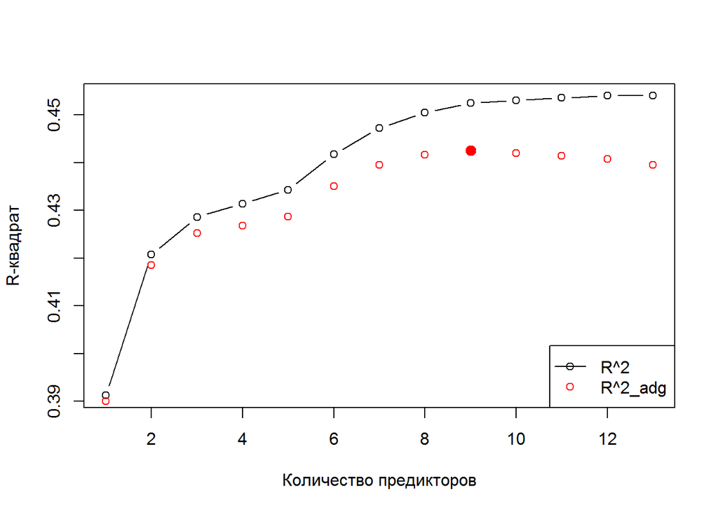

```r
points(which.max(reg.summary$adjr2),
       reg.summary$adjr2[which.max(reg.summary$adjr2)],
       col = 'red', cex = 2, pch = 20)
legend('bottomright', legend = c('R^2', 'R^2_adg'),
       col = c('black', 'red'), lty = c(1, NA),
       pch = c(1, 1))
```

```r
reg.summary$cp
```

```
##  [1] 46.548369 21.929562 16.886597 16.386124 15.728275 11.070003  8.069803
##  [8]  7.198756  7.414373  8.858957 10.405385 12.006558 14.000000
```

```r
# Число предикторов у оптимального значения критерия
which.min(reg.summary$cp)
```

```
## [1] 8
```

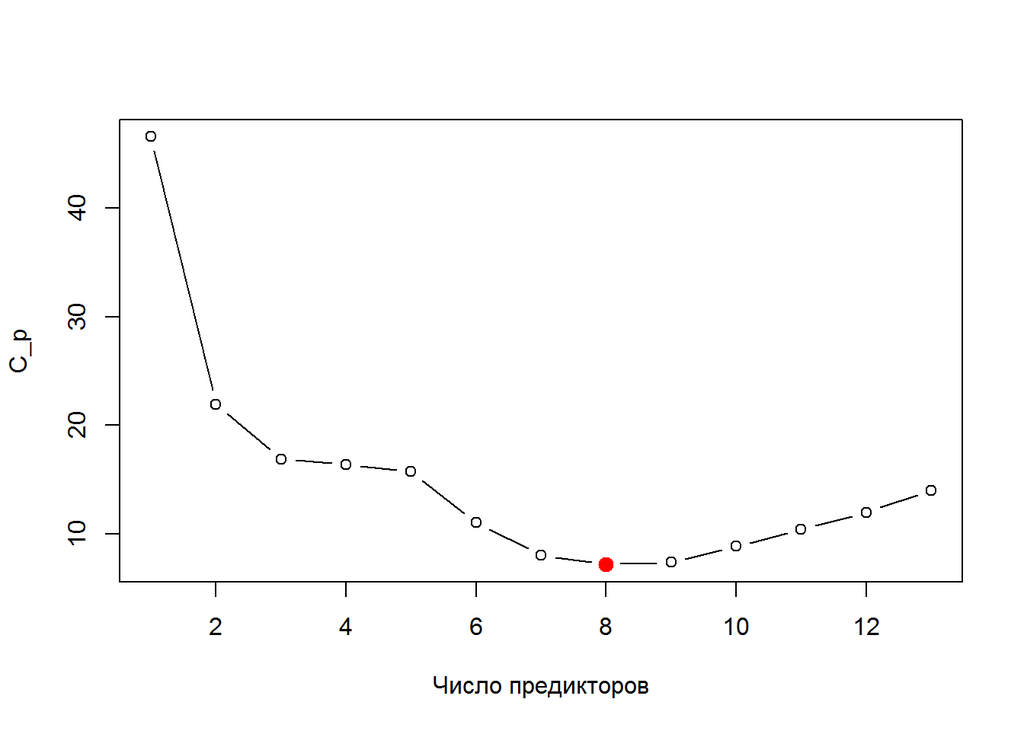

```r
# График
plot(reg.summary$cp, xlab = 'Число предикторов',
     ylab = 'C_p', type = 'b')
points(which.min(reg.summary$cp),
       reg.summary$cp[which.min(reg.summary$cp)],
       col = 'red', cex = 2, pch = 20)
```

```r
# BIC
reg.summary$bic
```

```
##  [1] -238.7044 -257.6477 -258.2957 -254.5324 -250.9374 -251.3640 -250.1920
##  [8] -246.8906 -242.4907 -236.8341 -231.0734 -225.2569 -219.0371
```

```r
# Число предикторов у оптимального значения критерия
which.min(reg.summary$bic)
```

```
## [1] 3
```

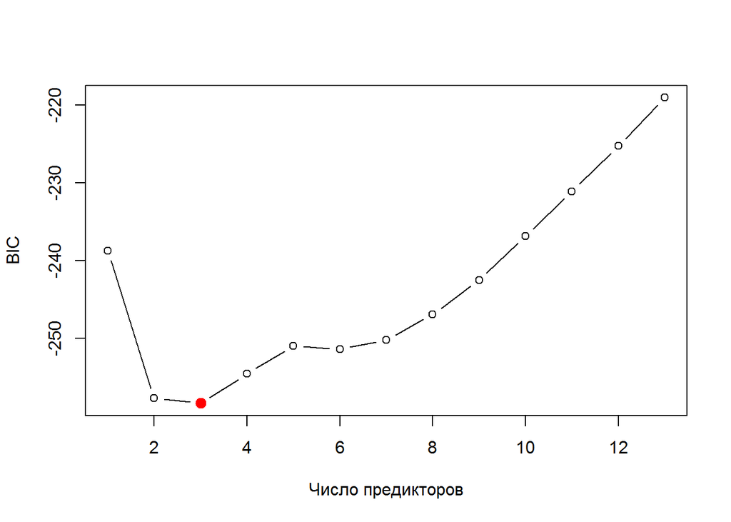

```r
### 3

# График
plot(reg.summary$bic, xlab = 'Число предикторов',
     ylab = 'BIC', type = 'b')
points(which.min(reg.summary$bic),
       reg.summary$bic[which.min(reg.summary$bic)],
       col = 'red', cex = 2, pch = 20)
```

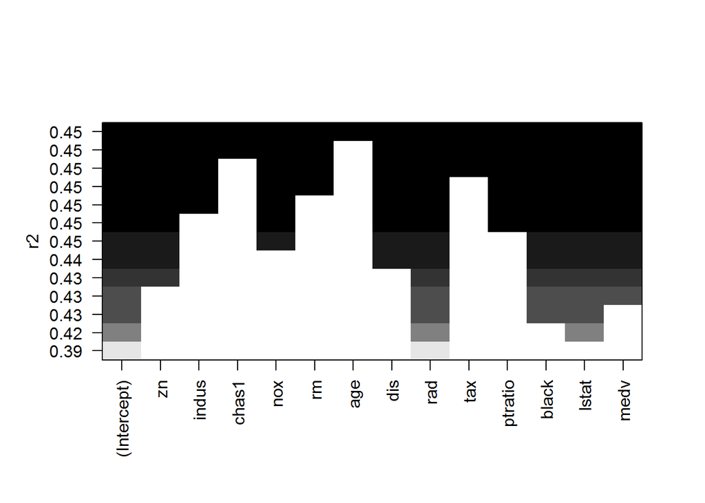

```r
# Метод plot для визуализации результатов
plot(regfit.fwd, scale = 'r2')
```

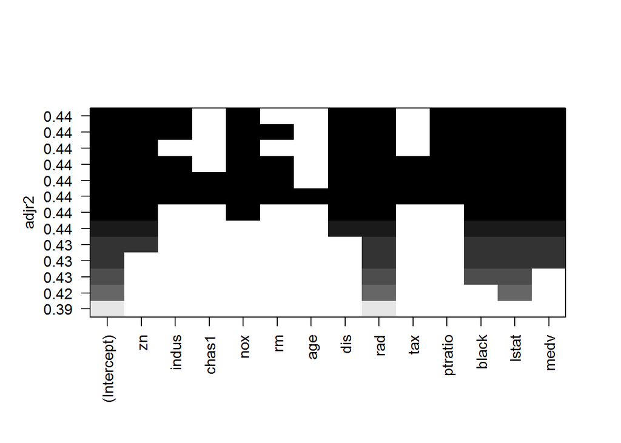

```r
plot(regfit.fwd, scale = 'adjr2')
```

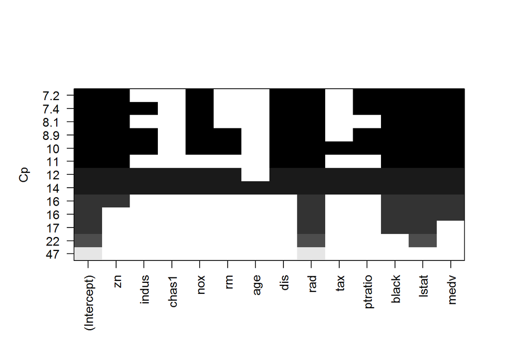

```r
plot(regfit.fwd, scale = 'Cp')
```

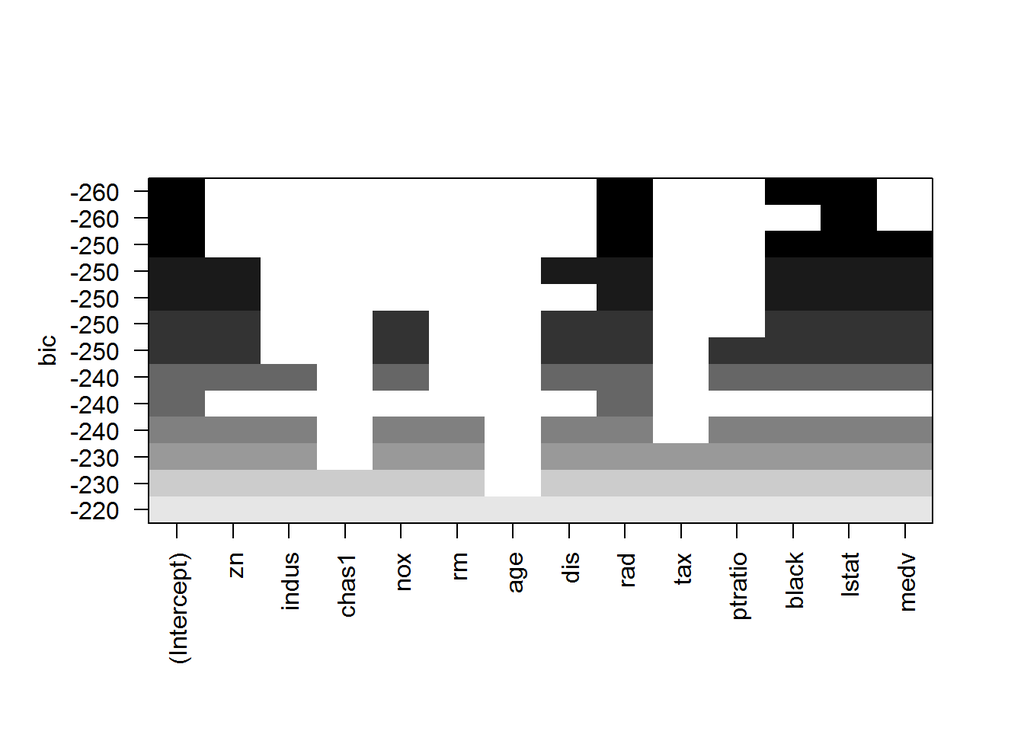

```r
plot(regfit.fwd, scale = 'bic')
```

```r
# Коэффициенты модели с наименьшим BIC
round(coef(regfit.fwd, 3), 3)
```

```
## (Intercept)         rad       black       lstat
##      -0.373       0.488      -0.009       0.214
```

## Нахождение оптимальной модели при помощи метода k-кратная кросс-валидация

```r
# функция для прогноза для функции regsubset()
predict.regsubsets <- function(object, newdata, id, ...){
    form <- as.formula(object$call[[2]])
    mat <- model.matrix(form, newdata)
    coefi <- coef(object, id = id)
    xvars <- names(coefi)
    mat[, xvars] %*% coefi
}




# отбираем 10 блоков наблюдений
k <- 10
set.seed(my.seed)
folds <- sample(1:k, nrow(Boston), replace = T)

# заготовка под матрицу с ошибками
cv.errors <- matrix(NA, k, 13, dimnames = list(NULL, paste(1:13)))

# заполняем матрицу в цикле по блокам данных
for (j in 1:k){
    best.fit <- regsubsets(crim ~ ., data = Boston[folds != j, ],
                           nvmax = 13)
    # теперь цикл по количеству объясняющих переменных
    for (i in 1:13){
        # модельные значения Salary
        pred <- predict(best.fit,Boston[folds == j, ], id = i)
        # вписываем ошибку в матрицу
        cv.errors[j, i] <- mean((Boston$crim[folds == j] - pred)^2)
    }
}

# усредняем матрицу по каждому столбцу (т.е. по блокам наблюдений),
#  чтобы получить оценку MSE для каждой модели с фиксированным
#  количеством объясняющих переменных
mean.cv.errors <- apply(cv.errors, 2, mean)
round(mean.cv.errors, 0)
```

```
##  1  2  3  4  5  6  7  8  9 10 11 12 13
## 44 43 44 45 44 44 43 43 43 43 43 43 43
```

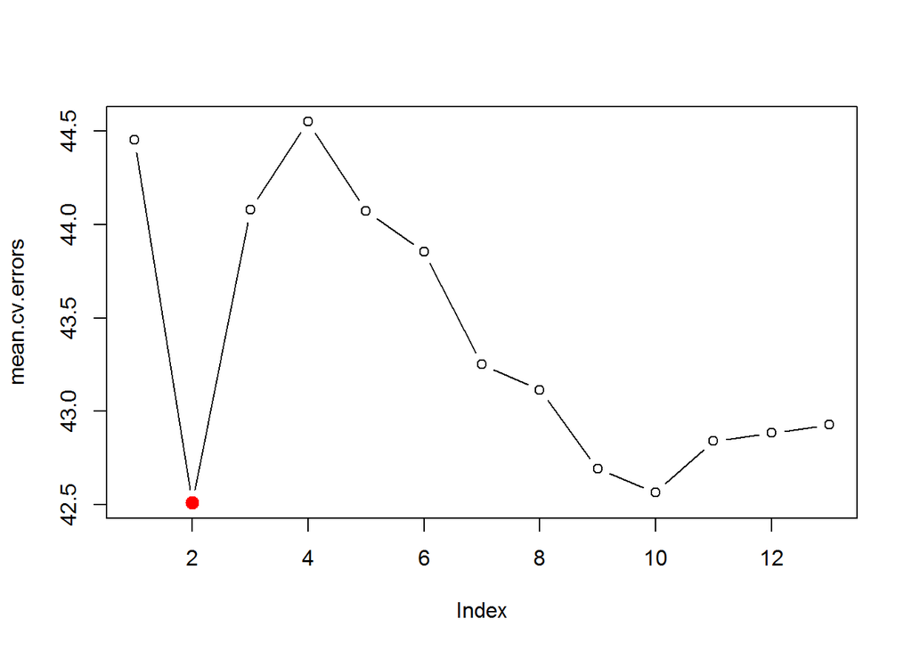

```r
# на графике
plot(mean.cv.errors, type = 'b')
points(which.min(mean.cv.errors), mean.cv.errors[which.min(mean.cv.errors)],
       col = 'red', pch = 20, cex = 2)
```

```r
reg.best <- regsubsets(crim ~ ., data = Boston, nvmax = 2)
round(coef(reg.best,2), 3)
```

```
## (Intercept)         rad       lstat
##      -4.381       0.523       0.237
```